# R parallel

This document is a brief introduction to basic parallel programming in R. First, we will go through a brief example to show the mechanics of the parallel code, and afterwards we will see at a real example.

### R Sequential loop

Lets start with an easy sequential loop. This bit of code makes the system wait for a specific amount of time, in this case 4 seconds:

```r
Sys.sleep(4)
```

So if we loop through a 3 element vector, each time using this function, the overall loop will take about 12 seconds

```r
time1 = Sys.time()
for (i in 1:3) {
  Sys.sleep(4)
  print(paste("Iteration",i))
}
```

```
## [1] "Iteration 1"
## [1] "Iteration 2"
## [1] "Iteration 3"
```

```r
time2 = Sys.time()
print(time2-time1)
```

```
## Time difference of 12.32561 secs
```

### Parallel loop

However, with a parallel approach, each run can be assigned to a worker, or a core of the computer or external server. This implies that the whole loop is processed within the time of a single loop.

There exist several packages that allow for parallel running, some of wich are specific to the operating system of a PCs. In my case, I have only tried “foreach” which is a function that allows for parallel running of for loops.

```
foreach(arguments) %dopar% {code}
```

However, neither R nor the function “foreach” know what do do with that bit of code. In how many workers does the task need to be splited? Before running anything in parallel, we need to establish what is called a “backend”. Again, there is a variety of available backends:

- doMC(only linux and mac)
- doParallel (works on Windows)
- doMPI (Useful for hundreds or thousands of workers)

I am using “doParallel”, and when loaded, the package already loads the “foreach” package.

```r
library(doParallel)
```

The function “makeCluster” allows us to create a “backend” of X many workers. Once created, the backend needs to be registered.

Normally, the maximum number of workers that would be able to handle a task at highest speed is the number of cores that a PC has - 1. However, several cores may be available in external servers, such as the one that we have at NORD.

(Curiosity for the audience: How many cores does our server has?)

```r
cl <- makeCluster(3)
registerDoParallel(cl)
```

```r
time1 = Sys.time()

foreach (i = 1:3) %dopar% { # %do% would make it run in sequential
  Sys.sleep(4)
  print(paste("Iteration",i))
}
```

```
## [[1]]
## [1] "Iteration 1"
##
## [[2]]
## [1] "Iteration 2"
##
## [[3]]
## [1] "Iteration 3"
```

```r
time2 = Sys.time()
print(time2-time1)
```

```
## Time difference of 4.137755 secs
```

After performing a task in parallel, it is very important to stop the Clustering, otherwise if we want to do further parallelisation in the code, we will be adding cores within cores, and problems will arise.

```r
stopCluster(cl)
rm(cl)
```

However, not everything is nice and easy in parallel, at least when you are starting as I am. There are things that I still not know how to do, and I am pretty sure that most of them derive from the fact that:

- Parallel tasks need to be independent!
- foreach takes the last element of the loop
- and returns it as a list

```r
cl <- makeCluster(3)
registerDoParallel(cl)

normal_math = foreach(i = 1:3) %dopar% {set.seed(3); rnorm(4, i)}
normal_math_df = foreach(i = 1:3, .combine = "cbind") %dopar% {set.seed(3);rnorm(4, i)}
normal_math_vector = foreach(i = 1:3, .combine = "c") %dopar% {set.seed(3);rnorm(4, i)}

stopCluster(cl)
rm(cl)

print(normal_math)
```

```
## [[1]]
## [1]  0.03806658  0.70747428  1.25878822 -0.15213189
##
## [[2]]
## [1] 1.0380666 1.7074743 2.2587882 0.8478681
##
## [[3]]
## [1] 2.038067 2.707474 3.258788 1.847868
```

```r
print(normal_math_df)
```

```
##         result.1  result.2 result.3
## [1,]  0.03806658 1.0380666 2.038067
## [2,]  0.70747428 1.7074743 2.707474
## [3,]  1.25878822 2.2587882 3.258788
## [4,] -0.15213189 0.8478681 1.847868
```

```r
print(normal_math_vector)
```

```
##  [1]  0.03806658  0.70747428  1.25878822 -0.15213189  1.03806658  1.70747428
##  [7]  2.25878822  0.84786811  2.03806658  2.70747428  3.25878822  1.84786811
```

For more information on parallel in R, check: https://www.youtube.com/watch?v=O8PiX9ofXDI&t=5540s

Now let’s look at a real example

# Fish data from Northern Norway

The IMR dataset contains community data from Shrimp trawl in the last decades.

```r
library(tidyverse)
data = read_csv("data_parallel.csv")
```

```
## * `` -> ...1
```

```r
head(data)
```

```
## # A tibble: 6 x 10
##    ...1 Species Longitude Latitude Bathymetry Salinity    Iron    DO   SST   SSS
##   <dbl>   <dbl>     <dbl>    <dbl>      <dbl>    <dbl>   <dbl> <dbl> <dbl> <dbl>
## 1     1       8     17.2      74.3       -181     34.8 1.04e-3  296.  3.42  34.7
## 2     2      12     20.3      73.9       -181     34.8 1.19e-3  303.  4.28  35.0
## 3     3       9     27.3      71.4       -275     34.7 1.39e-3  298.  6.31  34.5
## 4     4       9     26.5      72.9       -366     35.0 1.53e-3  300.  6.66  35.0
## 5     5      12     18.0      73.8       -225     34.9 1.06e-3  295.  5.87  35.0
## 6     6      10      9.07     79.3       -119     34.8 8.19e-4  307.  1.65  34.3
```

```r
data = data %>% dplyr::select(-1)
data
```

```
## # A tibble: 5,000 x 9
##    Species Longitude Latitude Bathymetry Salinity     Iron    DO   SST   SSS
##      <dbl>     <dbl>    <dbl>      <dbl>    <dbl>    <dbl> <dbl> <dbl> <dbl>
##  1       8     17.2      74.3       -181     34.8 0.00104   296.  3.42  34.7
##  2      12     20.3      73.9       -181     34.8 0.00119   303.  4.28  35.0
##  3       9     27.3      71.4       -275     34.7 0.00139   298.  6.31  34.5
##  4       9     26.5      72.9       -366     35.0 0.00153   300.  6.66  35.0
##  5      12     18.0      73.8       -225     34.9 0.00106   295.  5.87  35.0
##  6      10      9.07     79.3       -119     34.8 0.000819  307.  1.65  34.3
##  7       9     43.6      71.3       -202     34.8 0.00145   318.  4.50  34.6
##  8      11     13.6      80.4       -127     34.0 0.000798  305.  1.28  34.1
##  9       4      9.9      58.4       -549     29.8 0.000834  280.  9.89  31.0
## 10      13      8.02     57.5        -85     32.7 0.00133   278. 10.8   32.4
## # ... with 4,990 more rows
```

```r
library(dismo)
index <- sample(c(1,0), nrow(data), replace = T, prob = c(3,1))
train_data <- data.frame(data[which(index == 1),])
val_data   <- data[which(index != 1),]

brt_model = gbm.step(data = as.data.frame(train_data), gbm.x = 2:9, gbm.y = 1,
                     learning.rate = 0.2, family  = "gaussian", bag.fraction = 0.5, max.trees = 10000)
```

```
##
##
##  GBM STEP - version 2.9
##
## Performing cross-validation optimisation of a boosted regression tree model
## for Species and using a family of gaussian
## Using 3722 observations and 8 predictors
## creating 10 initial models of 50 trees
##
##  folds are unstratified
## total mean deviance =  14.4681
## tolerance is fixed at  0.0145
## ntrees resid. dev.
## 50    12.2347
## now adding trees...
## 100   11.9546
## 150   11.8207
## 200   11.7197
## 250   11.6968
## 300   11.7056
## 350   11.671
## 400   11.631
## 450   11.6355
## 500   11.6162
## 550   11.6437
## 600   11.6522
## 650   11.6004
## 700   11.6156
## 750   11.6513
## 800   11.6398
## 850   11.6137
## 900   11.6047
## 950   11.6324
## 1000   11.6423
## 1050   11.6835
## 1100   11.6783
## 1150   11.6822
```

```
## fitting final gbm model with a fixed number of 650 trees for Species
```

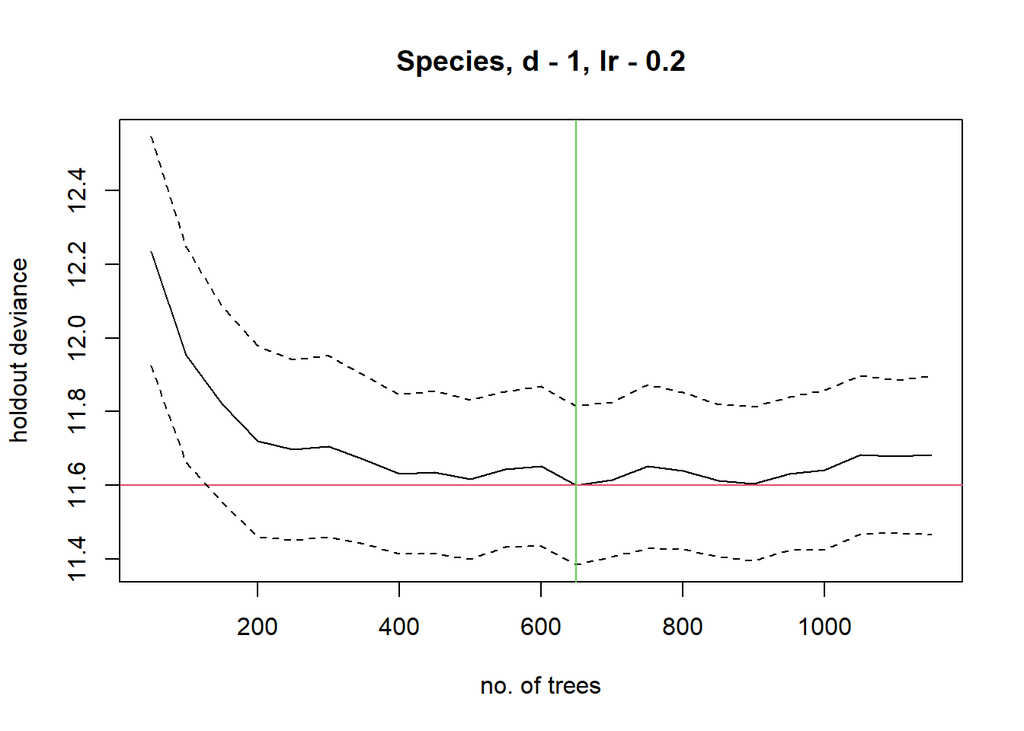

```
##
## mean total deviance = 14.468
## mean residual deviance = 9.965
##
## estimated cv deviance = 11.6 ; se = 0.215
##
## training data correlation = 0.564
## cv correlation =  0.447 ; se = 0.016
##
## elapsed time -  0.2 minutes
```

However, BRT results are partially random, and I would like to know the variability of the models. The uncertainty associated with the models. To do so, I may want to run several models and calculate the standar deviation of the predictions. But this takes a lot of time…. even more with real models and data. Therefore, we try to do it in parallel

```r
cl = makeCluster(3)
registerDoParallel(cl)

models = foreach(i = 1:3) %dopar% {

  train = train_data[sample(nrow(train_data), nrow(train_data),replace = T),]

  brt_model = gbm.step(data = as.data.frame(data_parallel), gbm.x = 2:9, gbm.y = 1,
                     learning.rate = 0.2, family  = "gaussian", bag.fraction = 0.5, max.trees = 10000)
}
```

```
## Error in {: task 1 failed - "could not find function "gbm.step""
```

```r
stopCluster(cl)
remove(cl)
```

But we get an Error message! It looks like I did not load the “dismo” package!

```r
library(dismo)

cl = makeCluster(3)
registerDoParallel(cl)

models = foreach(i = 1:3) %dopar% {

  train = train_data[sample(nrow(train_data), nrow(train_data),replace = T),]

  brt_model = gbm.step(data = as.data.frame(data_parallel), gbm.x = 2:9, gbm.y = 1,
                     learning.rate = 0.2, family  = "gaussian", bag.fraction = 0.5, max.trees = 10000)
}
```

```
## Error in {: task 1 failed - "could not find function "gbm.step""
```

```r
stopCluster(cl)
remove(cl)
```

The same problem again. What happened? Well, the thing is that once we give each worker a task, the packages from the master do not count anymore, so we have to load them within this task! (though the previously created functions are maintained)

```r
cl = makeCluster(3)
registerDoParallel(cl)

models = foreach(i = 1:3) %dopar% {
  library(dismo)

  train = train_data[sample(nrow(train_data), nrow(train_data),replace = T),]

  brt_model = gbm.step(data = train, gbm.x = 2:9, gbm.y = 1,
                     learning.rate = 0.2, family  = "gaussian", bag.fraction = 0.5, max.trees = 10000)
}

models
```

```
## [[1]]
## gbm::gbm(formula = y.data ~ ., distribution = as.character(family),
##     data = x.data, weights = site.weights, var.monotone = var.monotone,
##     n.trees = target.trees, interaction.depth = tree.complexity,
##     shrinkage = learning.rate, bag.fraction = bag.fraction, verbose = FALSE)
## A gradient boosted model with gaussian loss function.
## 9900 iterations were performed.
## There were 8 predictors of which 8 had non-zero influence.
##
## [[2]]
## gbm::gbm(formula = y.data ~ ., distribution = as.character(family),
##     data = x.data, weights = site.weights, var.monotone = var.monotone,
##     n.trees = target.trees, interaction.depth = tree.complexity,
##     shrinkage = learning.rate, bag.fraction = bag.fraction, verbose = FALSE)
## A gradient boosted model with gaussian loss function.
## 10000 iterations were performed.
## There were 8 predictors of which 8 had non-zero influence.
##
## [[3]]
## gbm::gbm(formula = y.data ~ ., distribution = as.character(family),
##     data = x.data, weights = site.weights, var.monotone = var.monotone,
##     n.trees = target.trees, interaction.depth = tree.complexity,
##     shrinkage = learning.rate, bag.fraction = bag.fraction, verbose = FALSE)
## A gradient boosted model with gaussian loss function.
## 9950 iterations were performed.
## There were 8 predictors of which 8 had non-zero influence.
```

```r
validation_results = foreach(i = 1:3, .combine = "cbind") %dopar% {
  library(gbm)
  library(dismo)

  model = models[[i]]
  validation = as.data.frame(array(0,c(2,0)))
  rownames(validation) = c("DV explained", "Correlation")
  pred <- predict.gbm(model, val_data, n.trees = model$gbm.call$best.trees, family = "poisson", type = "response")
  ext.residual.deviance <- calc.deviance(val_data$Species, pred, family = "poisson" ,calc.mean=T)
  ext.null.deviance <- calc.deviance(val_data$Species, family = "poisson", rep(mean(val_data$Species),nrow(val_data)), calc.mean=T)
  validation[1,1] <- (ext.null.deviance - ext.residual.deviance)/ext.null.deviance
  validation[2,1] <- cor(pred, val_data$Species)


  validation

}

print(validation_results)
```

```
##                      V1         V1         V1
## DV explained 0.06855418 0.03397458 0.05150471
## Correlation  0.36660768 0.34588221 0.35846708
```

```r
stopCluster(cl)
remove(cl)
```

This is all for today. Thank you!